```python
%reset
```

```
Once deleted, variables cannot be recovered. Proceed (y/[n])? y
```

[output not shown]

```python
import pandas as pd
import numpy as np
import os
%matplotlib inline
import matplotlib.pyplot as plt
import seaborn as sns
```

# 1. Introduction

## 1.1 Laod Datasets

#### Note: I've chosen StackOverFlow surveys 2019 to investigate

```python
directory= '/Users/hussam/Desktop/UDACITY/DataScientistND/P4/datasets'
file_names=[]
for filename in os.listdir(directory):
    file_names.append(filename)
```

```python
cd /Users/hussam/Desktop/UDACITY/DataScientistND/P4/datasets
```

```
/Users/hussam/Desktop/UDACITY/DataScientistND/P4/datasets
```

```python
pd.options.display.max_colwidth = 150
```

```python
ls
```

```
2011_Stack Overflow Survey Results.csv
2012 Stack Overflow Survey Results.csv
2013 Stack Overflow Survey Responses.csv
2014 Stack Overflow Survey Responses.csv
2015 Stack Overflow Developer Survey Responses.csv
2016 Stack Overflow Survey Responses.csv*
survey_results_public2018.csv
survey_results_public_2017.csv
survey_results_public_2019.csv
survey_results_schema_2017.csv
survey_results_schema_2018.csv
survey_results_schema_2019.csv
```

```python
df_2019=pd.read_csv('survey_results_public_2019.csv')
df_2019_schema=pd.read_csv('survey_results_schema_2019.csv')
```

### 1.2 Invetigating The Data

```python
df_2019.sample(3)
```

|  | Respondent | MainBranch | Hobbyist | OpenSourcer | OpenSource | Employment | Country | Student | EdLevel | UndergradMajor | ... | WelcomeChange | SONewContent | Age | Gender | Trans | Sexuality | Ethnicity | Dependents | SurveyLength | SurveyEase |
| --- | --- | --- | --- | --- | --- | --- | --- | --- | --- | --- | --- | --- | --- | --- | --- | --- | --- | --- | --- | --- | --- |
| 29049 | 29218 | I am a developer by profession | Yes | Less than once a month but more than once per year | The quality of OSS and closed source software is about the same | Not employed, but looking for work | Sri Lanka | No | Bachelor’s degree (BA, BS, B.Eng., etc.) | Information systems, information technology, or system administration | ... | A lot more welcome now than last year | Tech articles written by other developers;Industry news about technologies you're interested in;Tech meetups or events in your area;Courses on tec... | 31.0 | Man | No | Straight / Heterosexual | South Asian | Yes | Too long | Neither easy nor difficult |
| 75705 | 76180 | I am a developer by profession | Yes | Once a month or more often | OSS is, on average, of HIGHER quality than proprietary / closed source software | Employed full-time | United Kingdom | No | Master’s degree (MA, MS, M.Eng., MBA, etc.) | Computer science, computer engineering, or software engineering | ... | Just as welcome now as I felt last year | Tech articles written by other developers;Industry news about technologies you're interested in;Tech meetups or events in your area;Courses on tec... | 34.0 | Man | No | Straight / Heterosexual | Middle Eastern | No | Appropriate in length | Neither easy nor difficult |
| 27471 | 27632 | I am a developer by profession | Yes | Less than once per year | The quality of OSS and closed source software is about the same | Employed full-time | Canada | No | Bachelor’s degree (BA, BS, B.Eng., etc.) | Computer science, computer engineering, or software engineering | ... | Just as welcome now as I felt last year | Tech articles written by other developers | 48.0 | Man | No | Straight / Heterosexual | South Asian | Yes | Too long | Neither easy nor difficult |

3 rows × 85 columns

```python
df_2019.shape
```

```
(88883, 85)
```

```python
df_2019.info()
```

```
<class 'pandas.core.frame.DataFrame'>
RangeIndex: 88883 entries, 0 to 88882
Data columns (total 85 columns):
Respondent                88883 non-null int64
MainBranch                88331 non-null object
Hobbyist                  88883 non-null object
OpenSourcer               88883 non-null object
OpenSource                86842 non-null object
Employment                87181 non-null object
Country                   88751 non-null object
Student                   87014 non-null object
EdLevel                   86390 non-null object
UndergradMajor            75614 non-null object
EduOther                  84260 non-null object
OrgSize                   71791 non-null object
DevType                   81335 non-null object
YearsCode                 87938 non-null object
Age1stCode                87634 non-null object
YearsCodePro              74331 non-null object
CareerSat                 72847 non-null object
JobSat                    70988 non-null object
MgrIdiot                  61159 non-null object
MgrMoney                  61157 non-null object
MgrWant                   61232 non-null object
JobSeek                   80555 non-null object
LastHireDate              79854 non-null object
LastInt                   67155 non-null object
FizzBuzz                  71344 non-null object
JobFactors                79371 non-null object
ResumeUpdate              77877 non-null object
CurrencySymbol            71392 non-null object
CurrencyDesc              71392 non-null object
CompTotal                 55945 non-null float64
CompFreq                  63268 non-null object
ConvertedComp             55823 non-null float64
WorkWeekHrs               64503 non-null float64
WorkPlan                  68914 non-null object
WorkChallenge             68141 non-null object
WorkRemote                70284 non-null object
WorkLoc                   70055 non-null object
```

[output cut: 35 more lines]

```
SOJobs                    88066 non-null object
EntTeams                  87841 non-null object
SOComm                    88131 non-null object
WelcomeChange             85855 non-null object
SONewContent              69560 non-null object
Age                       79210 non-null float64
Gender                    85406 non-null object
Trans                     83607 non-null object
Sexuality                 76147 non-null object
Ethnicity                 76668 non-null object
Dependents                83059 non-null object
SurveyLength              86984 non-null object
SurveyEase                87081 non-null object
dtypes: float64(5), int64(1), object(79)
memory usage: 57.6+ MB
```

```python
start= 60
end= 80
```

```python
df_2019[df_2019.columns[start:end]].sample(3)
```

|  | OffOn | SocialMedia | Extraversion | ScreenName | SOVisit1st | SOVisitFreq | SOVisitTo | SOFindAnswer | SOTimeSaved | SOHowMuchTime | SOAccount | SOPartFreq | SOJobs | EntTeams | SOComm | WelcomeChange | SONewContent | Age | Gender | Trans |
| --- | --- | --- | --- | --- | --- | --- | --- | --- | --- | --- | --- | --- | --- | --- | --- | --- | --- | --- | --- | --- |
| 12191 | No | WeChat 微信 | Online | Username | 2018 | A few times per month or weekly | Learn how to do things I didn’t necessarily look for | Less than once per week | Stack Overflow was slightly faster | 11-30 minutes | Yes | Daily or almost daily | No, I knew that Stack Overflow had a job board but have never used or visited it | No, I've heard of them, but I am not part of a private Q&A instance | Neutral | A lot more welcome now than last year | Tech articles written by other developers;Courses on technologies you're interested in | 25.0 | Man | No |
| 86054 | Yes | Instagram | In real life (in person) | Username | 2018 | A few times per week | Find answers to specific questions | 3-5 times per week | Stack Overflow was much faster | 11-30 minutes | Yes | I have never participated in Q&A on Stack Overflow | No, I didn't know that Stack Overflow had a job board | No, and I don't know what those are | Yes, somewhat | Just as welcome now as I felt last year | Tech articles written by other developers | 22.0 | Man | No |
| 65643 | Yes | Twitter | Neither | NaN | 2009 | A few times per week | Find answers to specific questions;Contribute to a library of information | 1-2 times per week | They were about the same | NaN | Yes | Less than once per month or monthly | No, I knew that Stack Overflow had a job board but have never used or visited it | No, I've heard of them, but I am not part of a private Q&A instance | No, not really | Just as welcome now as I felt last year | NaN | 29.0 | Man | No |

```python
df_2019_schema.iloc[start:end]
```

|  | Column | QuestionText |
| --- | --- | --- |
| 60 | OffOn | Have you tried turning it off and on again? |
| 61 | SocialMedia | What social media site do you use the most? |
| 62 | Extraversion | Do you prefer online chat or IRL conversations? |
| 63 | ScreenName | What do you call it? |
| 64 | SOVisit1st | To the best of your memory, when did you first visit Stack Overflow? |
| 65 | SOVisitFreq | How frequently would you say you visit Stack Overflow? |
| 66 | SOVisitTo | I visit Stack Overflow to... (check all that apply) |
| 67 | SOFindAnswer | On average, how many times a week do you find (and use) an answer on Stack Overflow? |
| 68 | SOTimeSaved | Think back to the last time you solved a coding problem using Stack Overflow, as well as the last time you solved a problem using a different reso... |
| 69 | SOHowMuchTime | About how much time did you save? If you're not sure, please use your best estimate. |
| 70 | SOAccount | Do you have a Stack Overflow account? |
| 71 | SOPartFreq | How frequently would you say you participate in Q&A on Stack Overflow? By participate we mean ask, answer, vote for, or comment on questions. |
| 72 | SOJobs | Have you ever used or visited Stack Overflow Jobs? |
| 73 | EntTeams | Have you ever used Stack Overflow for Enterprise or Stack Overflow for Teams? |
| 74 | SOComm | Do you consider yourself a member of the Stack Overflow community? |
| 75 | WelcomeChange | Compared to last year, how welcome do you feel on Stack Overflow? |
| 76 | SONewContent | Would you like to see any of the following on Stack Overflow? Check all that apply. |
| 77 | Age | What is your age (in years)? If you prefer not to answer, you may leave this question blank. |
| 78 | Gender | Which of the following do you currently identify as? Please select all that apply. If you prefer not to answer, you may leave this question blank. |
| 79 | Trans | Do you identify as transgender? |

```python
df_2019.shape
```

```
(88883, 85)
```

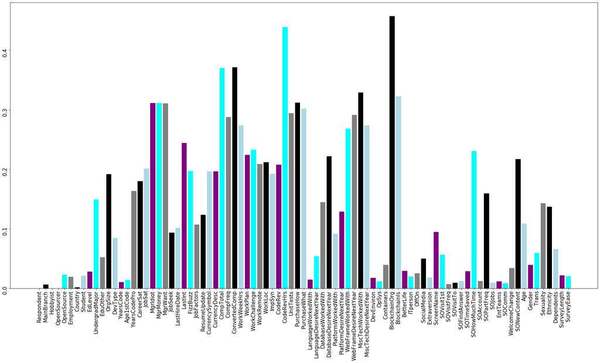

```python
plt.figure(figsize=(30,15))
plt.tick_params(labelsize=15,labelrotation=90)
plt.bar(x= df_2019.columns[:86],
        height= df_2019.isnull().mean()[:86],
        color= ['gray','black','lightblue','purple','cyan']);
```

# 2. Apply CRISP-DM

## 2.1 Business Understanding

### Through Surveyinng the data i've chosen the following question to answer:

- 1- What are common Programming Languages that are paid the most?
- 2- What is the Most common language with hobbyist?
- 3- Does More years, means more salary?
- 4- Most Desired programming languages between developers?
- 5- SO reputation over years between surveyed entities?

## 2.2 Data Understanding

### I've found the following features that will contribute in answering the questions mensioned:

- 1- What are common Programming Languages that are paid the most?
- Features: ConvertedComp,CompFreq,LanguageWorkedWith,MainBranch
- 2- What is the most common language with hobbyist?
- Features: LanguageWorkedWith,Hobbyist
- 3- Does More years, means more salary?
- Features: YearsCodePro,ConvertedComp,CompFreq
- 4- Most desired programming languages between developers?
- Features: LanguageDesireNextYear,MainBranch
- 5- SO reputation over years between surveyed entities?
- Features: SOVisit1st

## 2.3 Prepare Data

### In this Section, We'll clean and extract the data needed for our analysis.

```python
df_2019[['MainBranch', 'ConvertedComp', 'CompFreq', 'LanguageWorkedWith']].sample(3)
```

|  | MainBranch | ConvertedComp | CompFreq | LanguageWorkedWith |
| --- | --- | --- | --- | --- |
| 58296 | I am a developer by profession | 6144.0 | Monthly | C#;HTML/CSS;JavaScript;SQL;TypeScript |
| 78939 | I am a developer by profession | 175000.0 | Yearly | Bash/Shell/PowerShell;C;C++;HTML/CSS;Java;JavaScript;PHP;Python;SQL |
| 1991 | I am a student who is learning to code | NaN | NaN | C;C++ |

```python
df_2019.MainBranch.unique()
```

```
array(['I am a student who is learning to code',
       'I am not primarily a developer, but I write code sometimes as part of my work',
       'I am a developer by profession', 'I code primarily as a hobby',
       'I used to be a developer by profession, but no longer am', nan],
      dtype=object)
```

```python
# Re-encode MainBranch Features

main_branch={'I am a student who is learning to code': 'Student',
             'I am not primarily a developer, but I write code sometimes as part of my work': 'Sometimes',
             'I am a developer by profession': 'Developer',
             'I code primarily as a hobby': 'Hobby',
             'I used to be a developer by profession, but no longer am': 'Used to'}
df_2019.MainBranch.replace(main_branch,inplace=True)
```

```python
df_2019.MainBranch.sample(3)
```

```
30650      Student
68607    Developer
77600    Developer
Name: MainBranch, dtype: object
```

```python
# Re-encode LanguageWorkedWith
df_2019.LanguageWorkedWith.nunique()
```

```
20098
```

```python
df_2019[['LanguageWorkedWith','ConvertedComp']][:5]
```

|  | LanguageWorkedWith | ConvertedComp |
| --- | --- | --- |
| 0 | HTML/CSS;Java;JavaScript;Python | NaN |
| 1 | C++;HTML/CSS;Python | NaN |
| 2 | HTML/CSS | 8820.0 |
| 3 | C;C++;C#;Python;SQL | 61000.0 |
| 4 | C++;HTML/CSS;Java;JavaScript;Python;SQL;VBA | NaN |

```python
#Create a dataframe to calculate most paid programming language
language_l=[]
salary_l=[]

for i in np.arange(len(df_2019.LanguageWorkedWith)):

    if type(df_2019.LanguageWorkedWith[i]) != float:

        for j in np.arange(len(df_2019.LanguageWorkedWith[i].split(';'))):

            language_l.append(df_2019.LanguageWorkedWith[i].split(';')[j])

            if df_2019.CompFreq[i] == 'Monthly':
                salary= df_2019.ConvertedComp[i] *12


            elif df_2019.CompFreq[i] == 'Weekly':
                salary= df_2019.ConvertedComp[i] *52

            else:
                salary= df_2019.ConvertedComp[i]

            salary_l.append(salary)
df_dic={'Language': language_l, 'Salary': salary_l}
salaries=pd.DataFrame(df_dic)
```

```python
# preparing the data to caclulate the most common language with hobbyists.
hobbyist={'Yes':1,'No':0}
df_2019.Hobbyist.replace(hobbyist,inplace=True)
hob_df=df_2019.query('Hobbyist ==1')
```

```python
hob_df.head()
```

|  | Respondent | MainBranch | Hobbyist | OpenSourcer | OpenSource | Employment | Country | Student | EdLevel | UndergradMajor | ... | WelcomeChange | SONewContent | Age | Gender | Trans | Sexuality | Ethnicity | Dependents | SurveyLength | SurveyEase |
| --- | --- | --- | --- | --- | --- | --- | --- | --- | --- | --- | --- | --- | --- | --- | --- | --- | --- | --- | --- | --- | --- |
| 0 | 1 | Student | 1 | Never | The quality of OSS and closed source software is about the same | Not employed, and not looking for work | United Kingdom | No | Primary/elementary school | NaN | ... | Just as welcome now as I felt last year | Tech articles written by other developers;Industry news about technologies you're interested in;Courses on technologies you're interested in | 14.0 | Man | No | Straight / Heterosexual | NaN | No | Appropriate in length | Neither easy nor difficult |
| 2 | 3 | Sometimes | 1 | Never | The quality of OSS and closed source software is about the same | Employed full-time | Thailand | No | Bachelor’s degree (BA, BS, B.Eng., etc.) | Web development or web design | ... | Just as welcome now as I felt last year | Tech meetups or events in your area;Courses on technologies you're interested in | 28.0 | Man | No | Straight / Heterosexual | NaN | Yes | Appropriate in length | Neither easy nor difficult |
| 4 | 5 | Developer | 1 | Once a month or more often | OSS is, on average, of HIGHER quality than proprietary / closed source software | Employed full-time | Ukraine | No | Bachelor’s degree (BA, BS, B.Eng., etc.) | Computer science, computer engineering, or software engineering | ... | Just as welcome now as I felt last year | Tech meetups or events in your area;Courses on technologies you're interested in | 30.0 | Man | No | Straight / Heterosexual | White or of European descent;Multiracial | No | Appropriate in length | Easy |
| 5 | 6 | Sometimes | 1 | Never | The quality of OSS and closed source software is about the same | Employed full-time | Canada | No | Bachelor’s degree (BA, BS, B.Eng., etc.) | Mathematics or statistics | ... | Just as welcome now as I felt last year | Tech articles written by other developers;Industry news about technologies you're interested in;Tech meetups or events in your area;Courses on tec... | 28.0 | Man | No | Straight / Heterosexual | East Asian | No | Too long | Neither easy nor difficult |
| 7 | 8 | Hobby | 1 | Less than once per year | OSS is, on average, of HIGHER quality than proprietary / closed source software | Not employed, but looking for work | India | NaN | Bachelor’s degree (BA, BS, B.Eng., etc.) | Computer science, computer engineering, or software engineering | ... | A lot more welcome now than last year | Tech articles written by other developers;Industry news about technologies you're interested in;Tech meetups or events in your area;Courses on tec... | 24.0 | Man | No | Straight / Heterosexual | NaN | NaN | Appropriate in length | Neither easy nor difficult |

5 rows × 85 columns

```python
# Prepare the data to answer the third question
```

```python
df_2019[['YearsCodePro','ConvertedComp','CompFreq']].head()
```

|  | YearsCodePro | ConvertedComp | CompFreq |
| --- | --- | --- | --- |
| 0 | NaN | NaN | NaN |
| 1 | NaN | NaN | NaN |
| 2 | 1 | 8820.0 | Monthly |
| 3 | Less than 1 year | 61000.0 | Yearly |
| 4 | 9 | NaN | NaN |

```python
df_2019.YearsCodePro.unique()
```

```
array([nan, '1', 'Less than 1 year', '9', '3', '4', '10', '8', '2', '13',
       '18', '5', '14', '22', '23', '19', '35', '20', '25', '7', '15',
       '27', '6', '48', '12', '31', '11', '17', '16', '21', '29', '30',
       '26', '33', '28', '37', '40', '34', '24', '39', '38', '36', '32',
       '41', '45', '43', 'More than 50 years', '44', '42', '46', '49',
       '50', '47'], dtype=object)
```

```python
''''intervals= {
    'Less than 1 year':'1-5 years','1':'1-5 years','2':'1-5 years','3':'1-5 years','4':'1-5 years','5':'1-5 years',
    '6':'6-10','7':'6-10','8':'6-10','9':'6-10','10':'6-10',
    '11':'11-20','12':'11-20','13':'11-20','14':'11-20','15':'11-20','16':'11-20','17':'11-20','18':'11-20','19':'11-20','20':'11-20',
    '21':'21-30','22':'21-30','23':'21-30','24':'21-30','25':'21-30','26':'21-30','27':'21-30','28':'21-30','29':'21-30','30':'21-30',
    '31' : 'More than 30','32': 'More than 30', '33': 'More than 30', '34': 'More than 30', '35': 'More than 30', '36': 'More than 30', '37': 'More than 30' ,'38': 'More than 30', '39': 'More than 30',
     '40': 'More than 30', '41': 'More than 30', '42': 'More than 30','43': 'More than 30', '44': 'More than 30' ,'45' : 'More than 30','46': 'More than 30', '47': 'More than 30', '48': 'More than 30' ,'49': 'More than 30', '50': 'More than 30','More than 50 years': 'More than 30'}
df_2019.YearsCodePro.replace(intervals,inplace=True)
df_2019.YearsCodePro.head()'''
```

[output not shown]

```python
intervals= {'Less than 1 year':0,'More than 50 years': 51}
df_2019.YearsCodePro.replace(intervals,inplace=True)
df_2019.YearsCodePro=df_2019.YearsCodePro.astype(float)
df_2019.YearsCodePro.head()
```

```
0    NaN
1    NaN
2    1.0
3    0.0
4    9.0
Name: YearsCodePro, dtype: float64
```

```python
df_2019[['ConvertedComp','CompFreq']].sample(10)
```

|  | ConvertedComp | CompFreq |
| --- | --- | --- |
| 20159 | 35005.0 | Yearly |
| 11624 | NaN | NaN |
| 58996 | NaN | NaN |
| 22122 | NaN | NaN |
| 7992 | NaN | NaN |
| 42112 | 36664.0 | Yearly |
| 27579 | NaN | NaN |
| 33991 | 179300.0 | Yearly |
| 317 | NaN | Monthly |
| 25891 | NaN | NaN |

```python
adj_comp=[]
for i in np.arange(len(df_2019.CompFreq)):
    if df_2019.CompFreq[i] == "Monthly":
        adj_comp.append(df_2019.ConvertedComp[i]*12)
    elif df_2019.CompFreq[i] == "Weekly":
        adj_comp.append(df_2019.ConvertedComp[i]*52)
    else:
        adj_comp.append(df_2019.ConvertedComp[i])

df_2019['ConvertedComp'] = adj_comp
```

```python
# preparation for question four
```

```python
df_2019[['LanguageDesireNextYear','MainBranch']].head()
```

|  | LanguageDesireNextYear | MainBranch |
| --- | --- | --- |
| 0 | C;C++;C#;Go;HTML/CSS;Java;JavaScript;Python;SQL | Student |
| 1 | C++;HTML/CSS;JavaScript;SQL | Student |
| 2 | Elixir;HTML/CSS | Sometimes |
| 3 | C;C#;JavaScript;SQL | Developer |
| 4 | HTML/CSS;Java;JavaScript;SQL;WebAssembly | Developer |

```python
# Preperation for Q5
```

```python
df_2019.SOVisit1st.sample(3)
```

```
87509    2016
74859    2014
83502    2018
Name: SOVisit1st, dtype: object
```

### 2.4 Modeling

##### Q1) What are common Programming Languages that are paid the most?

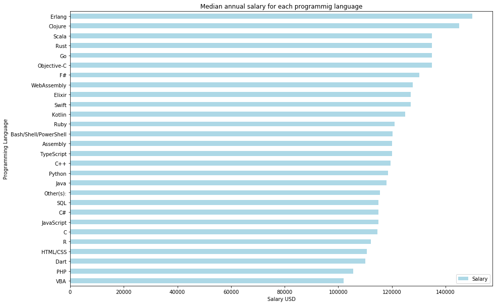

```python
# Median Yearly salary per language
salaries.groupby(['Language']).median().sort_values('Salary').plot.barh(color= 'lightblue',figsize=(15,10));
plt.ylabel('Programming Language');
plt.xlabel('Salary USD');
plt.title('Median annual salary for each programmig language');
```

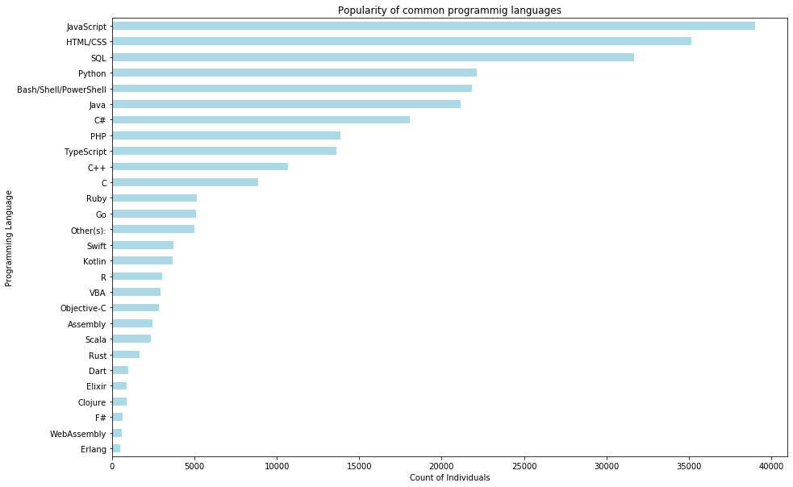

```python
#Popularity of each language
salaries.groupby(['Language']).count().sort_values('Salary').plot.barh(legend=False,color= ['lightblue'],figsize=(15,10));
plt.ylabel('Programming Language');
plt.xlabel('Count of Individuals');
plt.title('Popularity of common programmig languages');
```

#### From the analysis made above, we can notice that the highest paid languages are Erlang & Clojure.

### Q2) What are the most common languages with hobbyists?

```python
hob_df=df_2019.query('Hobbyist== 1')
```

```python
hob_df.LanguageWorkedWith.nunique()
```

```
18370
```

```python
hob_df.shape
```

```
(71257, 85)
```

```python
hob_l=[]
for i in np.arange(len(hob_df.LanguageWorkedWith)):
    try:
        for j in np.arange(len(hob_df.LanguageWorkedWith[i].split(';'))):
            hob_l.append(hob_df.LanguageWorkedWith[i].split(';')[j])

    except:
        continue
```

```python
hob_s=list(set(hob_l))
hob_c=[]
for i in np.arange(len(hob_s)):
    hob_c.append(hob_l.count(hob_s[i]))
```

```python
hobb=pd.DataFrame({'language':hob_s,'count':hob_c})
```

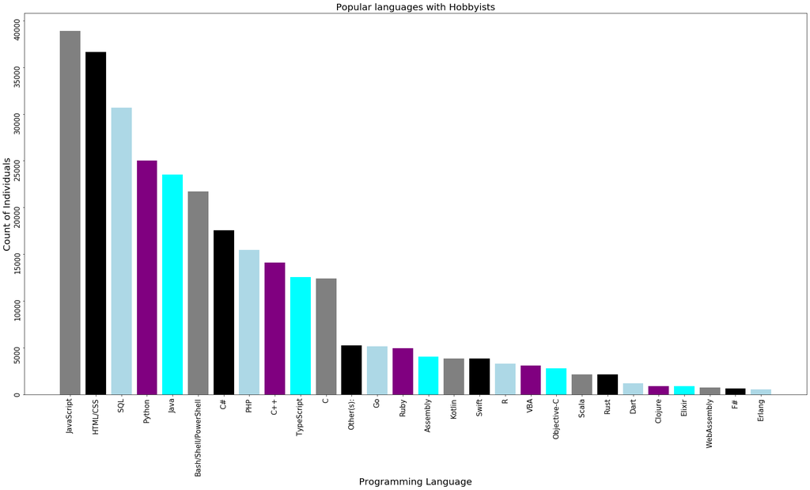

```python
plt.figure(figsize=(30,15))
plt.tick_params(labelsize=15,labelrotation=90)
plt.bar(x= hobb.sort_values('count',ascending=False).language.values,
        height= hobb.sort_values('count',ascending=False)['count'].values,
        color= ['gray','black','lightblue','purple','cyan']);
plt.xlabel('Programming Language',fontdict={'fontsize': 20});
plt.ylabel('Count of Individuals',fontdict={'fontsize': 20});
plt.title('Popular languages with Hobbyists',fontdict={'fontsize': 20});
```

### Q3)Does More years, means more salary?

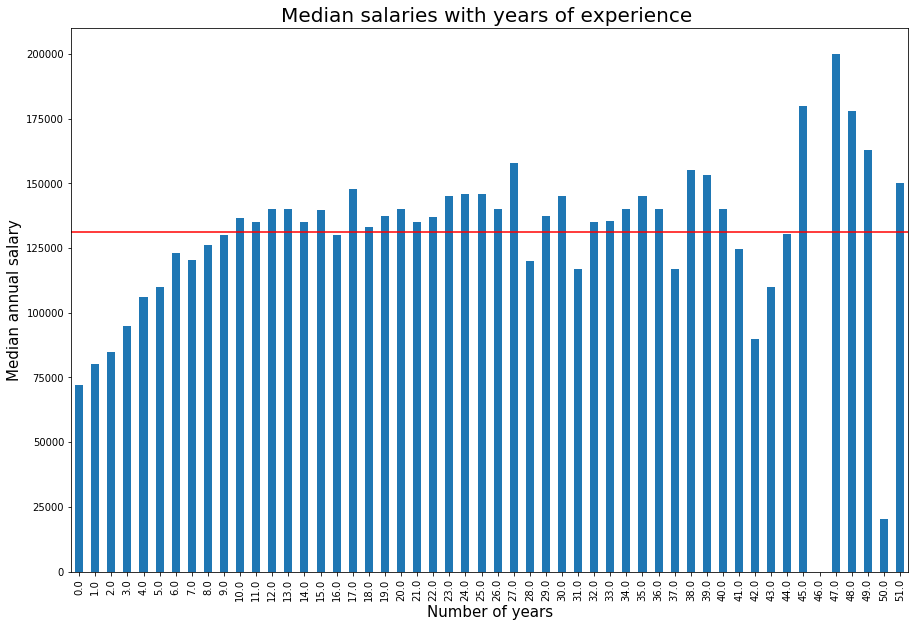

```python
df_2019.groupby('YearsCodePro')['ConvertedComp'].median().plot.bar(figsize=(15,10));
plt.axhline(y=df_2019.groupby('YearsCodePro')['ConvertedComp'].median().mean(), color='r', linestyle='-');
plt.xlabel('Number of years',fontdict={'fontsize': 15});
plt.ylabel('Median annual salary',fontdict={'fontsize': 15});
plt.title('Median salaries with years of experience ',fontdict={'fontsize': 20});
```

```python
df_2019[['ConvertedComp','YearsCodePro']].corr()
```

|  | ConvertedComp | YearsCodePro |
| --- | --- | --- |
| ConvertedComp | 1.000000 | 0.010352 |
| YearsCodePro | 0.010352 | 1.000000 |

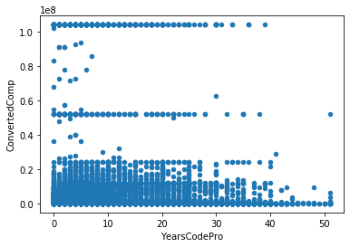

```python
df_2019.plot.scatter('YearsCodePro','ConvertedComp');
```

#### As seen a bove we conclude that more years in coding doesn't necessarily imply more salary.

```python
df_2019[['LanguageDesireNextYear','MainBranch']].head()
```

|  | LanguageDesireNextYear | MainBranch |
| --- | --- | --- |
| 0 | C;C++;C#;Go;HTML/CSS;Java;JavaScript;Python;SQL | Student |
| 1 | C++;HTML/CSS;JavaScript;SQL | Student |
| 2 | Elixir;HTML/CSS | Sometimes |
| 3 | C;C#;JavaScript;SQL | Developer |
| 4 | HTML/CSS;Java;JavaScript;SQL;WebAssembly | Developer |

```python
df_dev= df_2019.query("MainBranch == 'Developer'")
```

```python
dev_l=[]
for i in np.arange(len(df_dev.LanguageWorkedWith)):
    try:
        for j in np.arange(len(df_dev.LanguageWorkedWith[i].split(';'))):
            dev_l.append(df_dev.LanguageWorkedWith[i].split(';')[j])

    except:
        continue
```

```python
dev_s=list(set(dev_l))
dev_c=[]
for i in np.arange(len(dev_s)):
    dev_c.append(dev_l.count(dev_s[i]))
```

```python
dev=pd.DataFrame({'language':dev_s,'count':dev_c})
```

[figure not shown]

```python
plt.figure(figsize=(30,15))
plt.tick_params(labelsize=15,labelrotation=90)
plt.bar(x= dev.sort_values('count',ascending=False).language.values,
        height= dev.sort_values('count',ascending=False)['count'].values,
        color= ['gray','black','lightblue','purple','cyan']);
plt.title('Desired Programming Languages Between Developers',fontdict={'fontsize': 25});
plt.xlabel('Programming Languages',fontdict={'fontsize': 20});
plt.ylabel('Count of Individuals',fontdict={'fontsize': 20});
```

### Q5) SO reputation over years between surveyed entities?

```python
df_2019.SOVisit1st.dropna(inplace=True)
```

```python
df_2019.SOVisit1st.unique()
```

```
array(['2017', '2011', '2014', "I don't remember", '2012', '2013', '2010',
       '2018', '2008', '2016', '2015', '2009', '2019'], dtype=object)
```

```python
(df_2019.SOVisit1st=="I don't remember").sum()
```

```
10383
```

```python
len(df_2019.SOVisit1st)
```

```
83877
```

```python
df_2019.drop(df_2019.SOVisit1st[df_2019.SOVisit1st=="I don't remember"].index,inplace=True)
```

```python
df_2019.SOVisit1st=df_2019.SOVisit1st.astype('float')
```

```python
df_2019.SOVisit1st.dropna(inplace=True)
```

```python
df_2019.SOVisit1st.isnull().sum()
```

```
0
```

```python
sov_s=list(df_2019.SOVisit1st.unique())
```

```python
sov_s
```

```
[2017.0,
 2011.0,
 2014.0,
 2012.0,
 2013.0,
 2010.0,
 2018.0,
 2008.0,
 2016.0,
 2015.0,
 2009.0,
 2019.0]
```

```python
sov_s[1].dtype
```

```
dtype('float64')
```

```python
sol=list(df_2019.SOVisit1st)
```

```python
sov_c=[]
for i in np.arange(len(sov_s)):
    sov_c.append(sol.count(sov_s[i]))
```

```python
sov_df=pd.DataFrame({'year':sov_s,'count':sov_c})
```

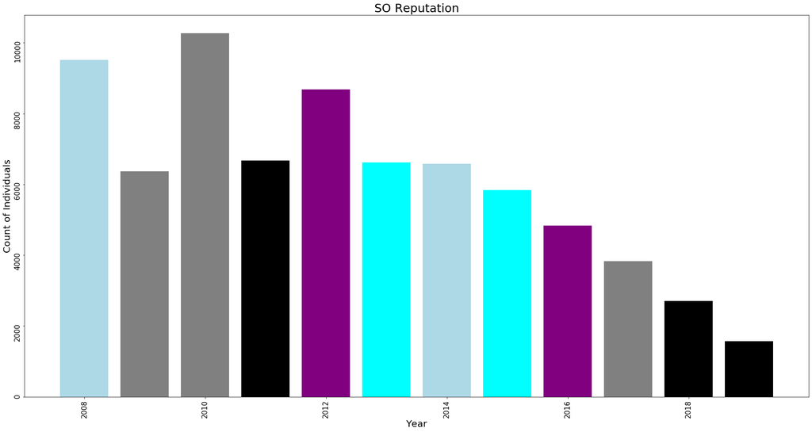

```python
plt.figure(figsize=(30,15))
plt.tick_params(labelsize=15,labelrotation=90)
plt.bar(x= sov_df.year.values,
        height= sov_df['count'].values,
        color= ['gray','black','lightblue','purple','cyan']);
plt.title('SO Reputation',fontdict={'fontsize': 25});
plt.xlabel('Year',fontdict={'fontsize': 20});
plt.ylabel('Count of Individuals',fontdict={'fontsize': 20});
```